# Supplier Management

## Reducing bad suppliers can significantly increase Olist profits and profit margins

[output not shown]

# Why removing the bad suppliers will increase our Profits?

## There are 2 reasons:

### Bad suppliers will cost us more Reputation fees

#### Consumers prone to give lower review score for the bad suppliers, which would cost Olist more money to fix the reputation and win back the market. It would cost Olist avarage 393 BRL more to fix the reputation for the bad suppliers.

|  | review_score | cost_of_reviews | revenues | profits |
| --- | --- | --- | --- | --- |
| mean | 4.101513 | 545.402764 | 938.934427 | 393.531663 |
| min | 1.000000 | 0.000000 | 0.650000 | -21519.517000 |
| max | 5.000000 | 39400.000000 | 24387.263000 | 18067.605000 |

|  | review_score | cost_of_reviews | revenues | profits |
| --- | --- | --- | --- | --- |
| mean | 3.905583 | 938.222222 | 588.134542 | -350.087681 |
| min | 1.000000 | 0.000000 | 0.650000 | -21519.517000 |
| max | 5.000000 | 39400.000000 | 21647.292000 | 48.650000 |

```
335175.033
```

### Less items/ less suppliers we use would save us the IT cost fee

#### Using 2967 supplier would cost Olist around 500K BRL, while removing 855 bad suppliers, it saves around 104K BRL in the IT Cost fees

- Current IT Cost is 500K BRL
- After removing bad suppliers the IT cost is around 396K BRL

# Reducing the suppliers of course will reduce our subscription fee and sales fee

- Each supplier's subscribe fee is 80 BRL per month
- As the reduction of the product and orders, Sales fee will reduce around 335K BRL

## Need to find the maximum profits by balancing the cost and revenue

```
IT_cost is 499999.31851932954
Current Profit is 667609.1254806706
Current Profit Margin is 23.96455974790978
```

```
395957.2949837017
```

|  | removed_seller | profits | Profit_Margin |
| --- | --- | --- | --- |
| 0 | 1 | 692136.571883 | 24.968420 |
| 1 | 2 | 712856.431848 | 25.918276 |
| 2 | 3 | 733114.115269 | 26.771116 |
| 3 | 4 | 750492.262699 | 27.452607 |
| 4 | 5 | 764944.796635 | 28.007435 |
| ... | ... | ... | ... |
| 2961 | 2962 | 10161.055257 | 11.686820 |
| 2962 | 2963 | 10133.560921 | 14.001766 |
| 2963 | 2964 | 5960.831718 | 9.377538 |
| 2964 | 2965 | 1435.806075 | 3.373542 |
| 2965 | 2966 | -4897.312828 | -21.074947 |

2966 rows × 3 columns

|  | removed_seller | profits | Profit_Margin |
| --- | --- | --- | --- |
| 854 | 855 | 1.070976e+06 | 46.911664 |
| 852 | 853 | 1.070976e+06 | 46.902676 |
| 853 | 854 | 1.070969e+06 | 46.904208 |
| 855 | 856 | 1.070968e+06 | 46.913110 |
| 876 | 877 | 1.070966e+06 | 47.004579 |
| ... | ... | ... | ... |
| 2959 | 2960 | 9.750434e+03 | 8.108315 |
| 2963 | 2964 | 5.960832e+03 | 9.377538 |
| 2960 | 2961 | 5.303323e+03 | 4.763528 |
| 2964 | 2965 | 1.435806e+03 | 3.373542 |
| 2965 | 2966 | -4.897313e+03 | -21.074947 |

2966 rows × 3 columns

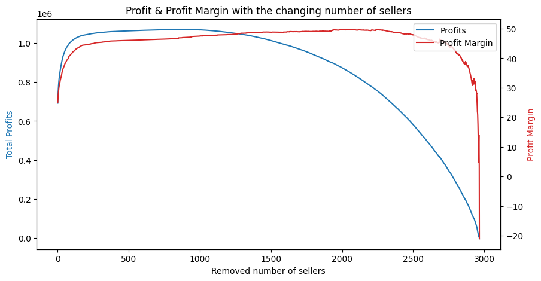